# Relative healthcare use (CKD stage 4/5)

Transplant appointments (overall)

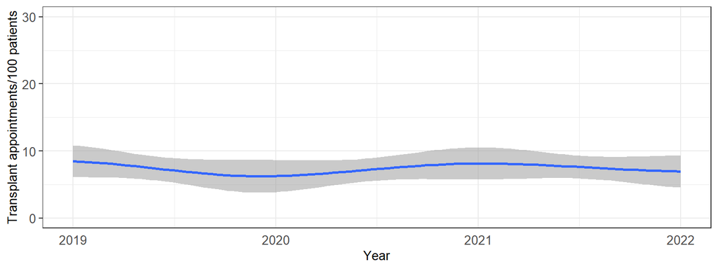

Transplant appointments by ethnicity

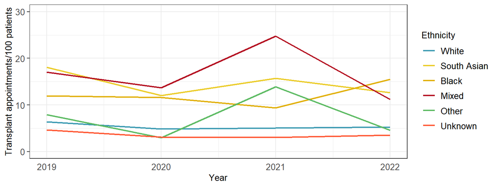

Transplant appointments by IMD

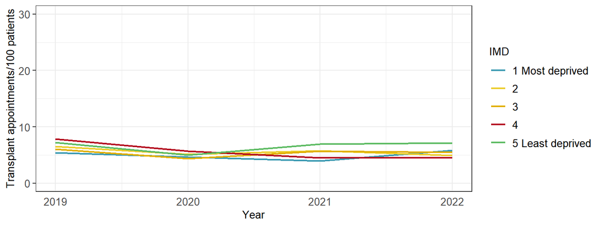

Transplant appointments by rural/urban

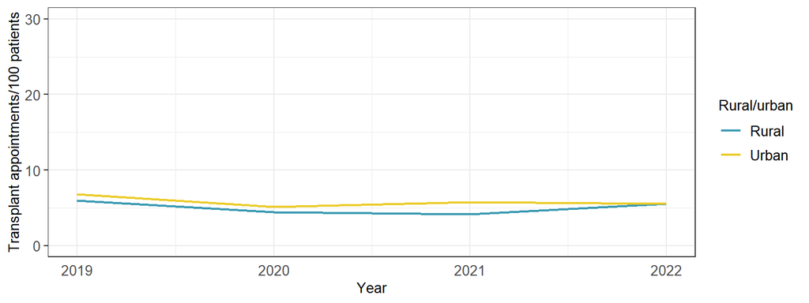

**GP interactions**

GP interactions (overall)

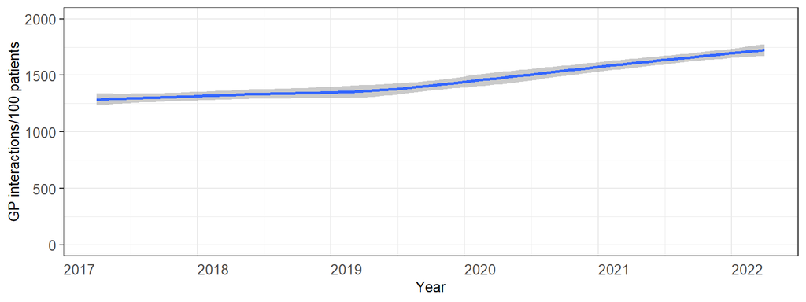

GP interactions by ethnicity

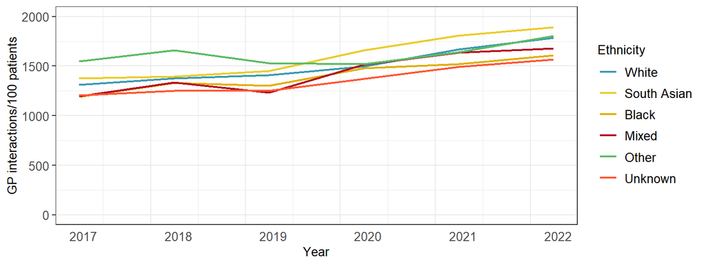

GP interactions by IMD

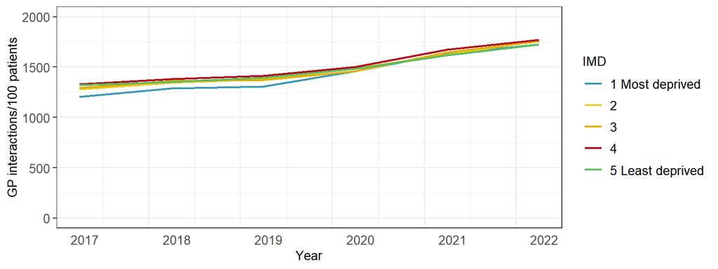

GP interactions by region

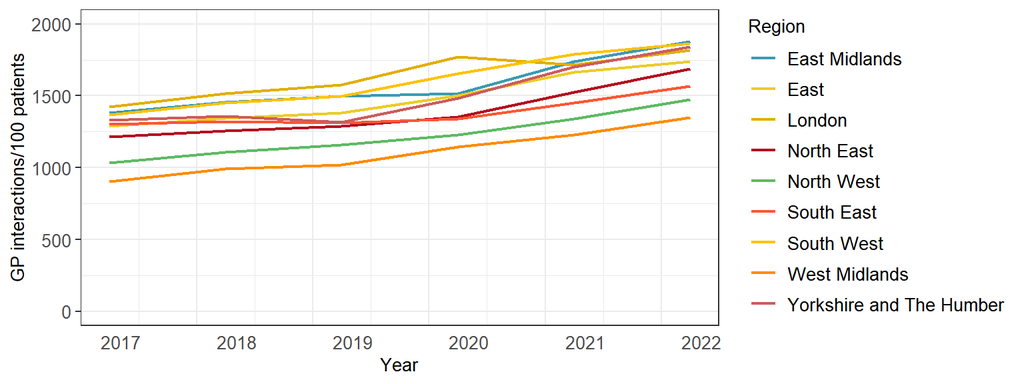

GP interactions by rural/urban

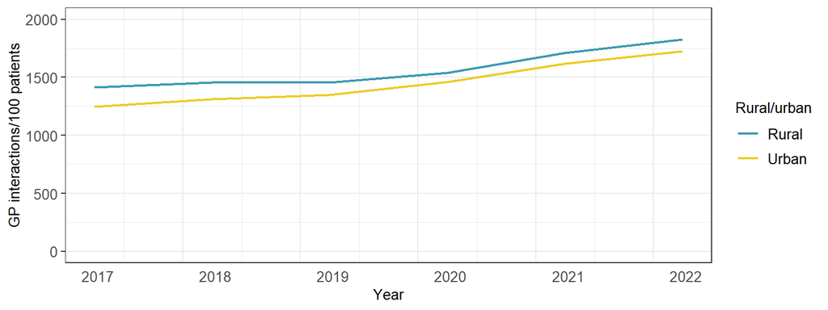

**Blood pressure measurements**

Blood pressure measurements (overall)

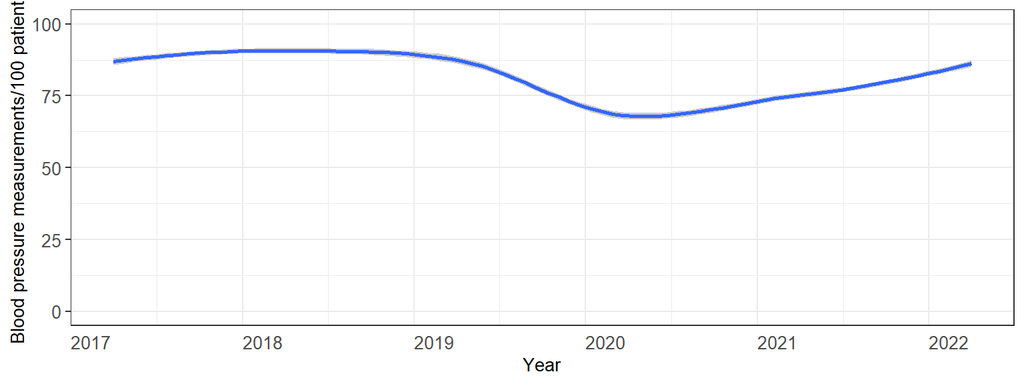

Blood pressure measurements by ethnicity

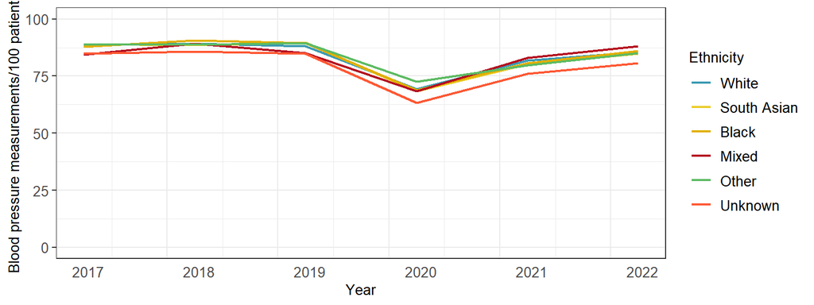

Blood pressure measurements by IMD

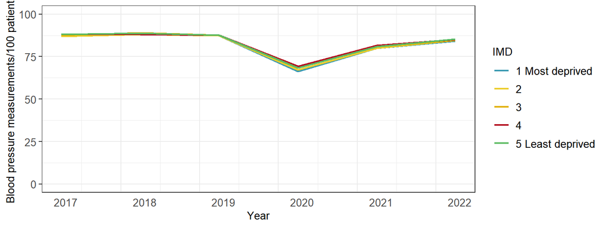

Blood pressure measurements by region

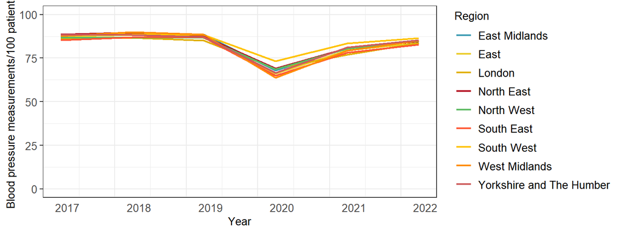

Blood pressure measurements by rural/urban

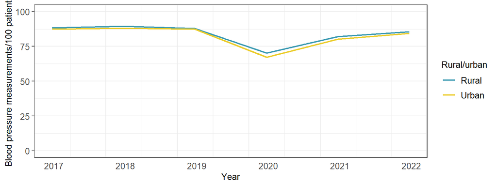

**uACR measurements**

uACR measurements (overall)

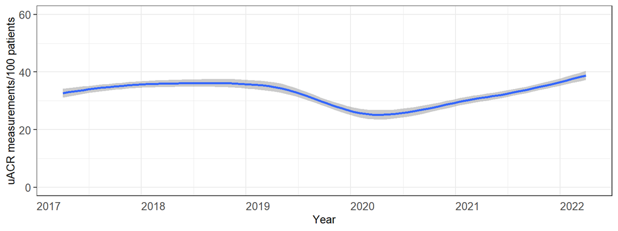

uACR measurements by ethnicity

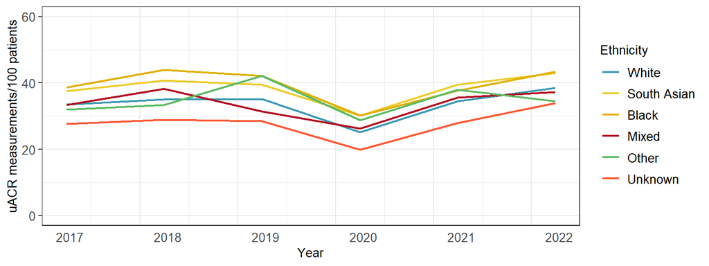

uACR measurements by IMD

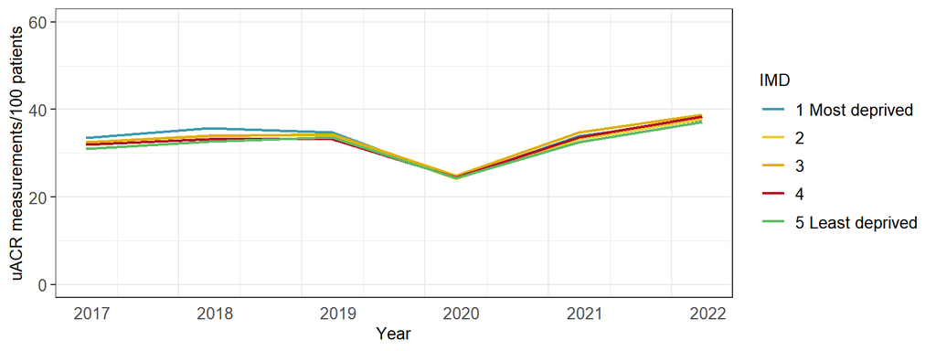

uACR measurements by region

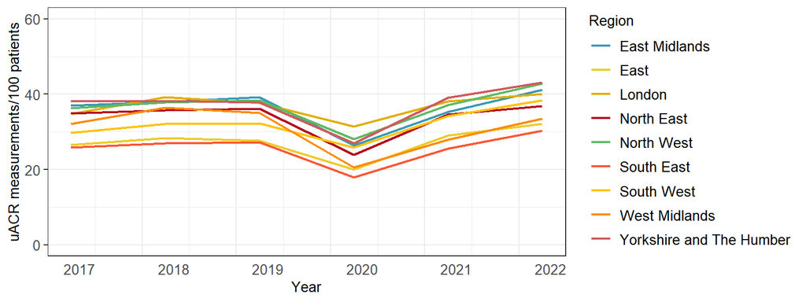

uACR measurements by rural/urban

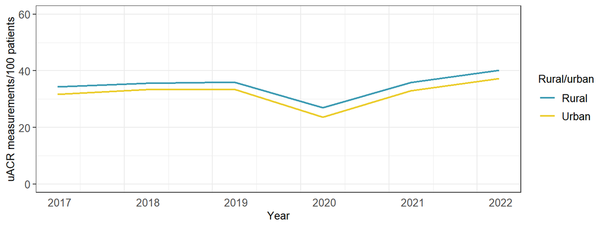

**SCr measurements**

SCr measurements (overall)

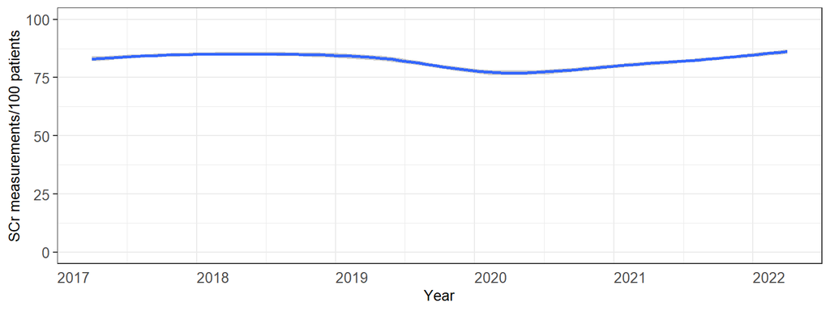

SCr measurements by ethnicity

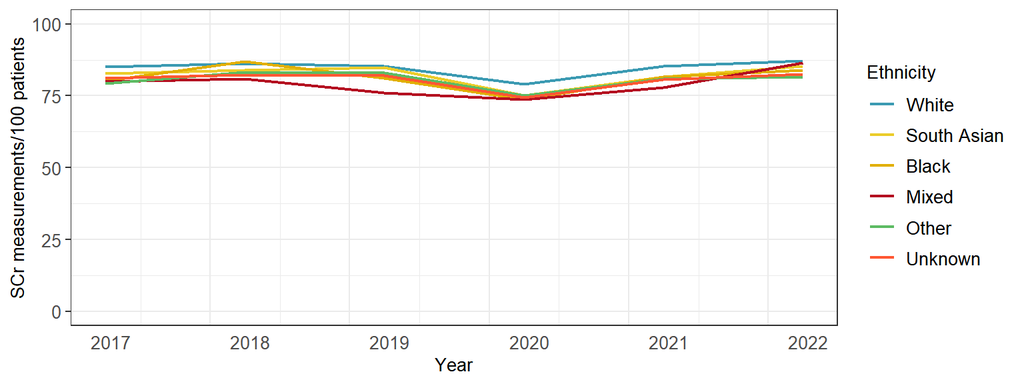

SCr measurements by IMD

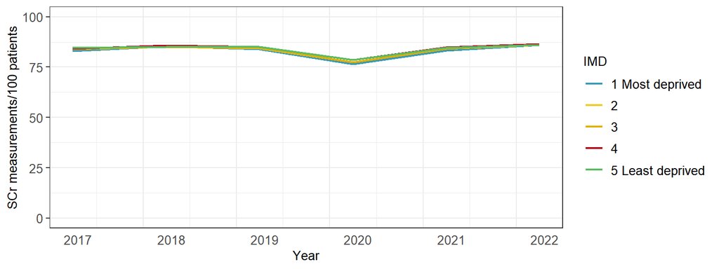

SCr measurements by region

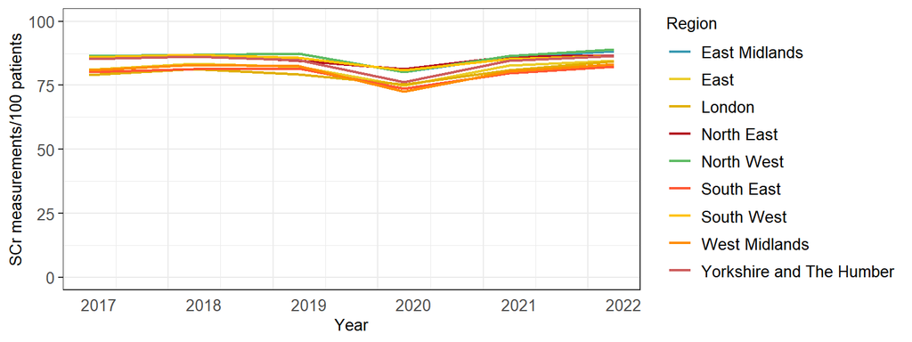

SCr measurements by rural/urban

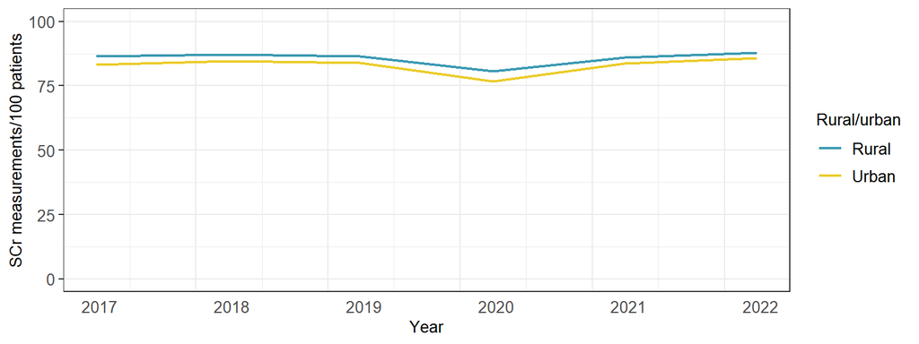

**AVF formations**

AVF formations (overall)

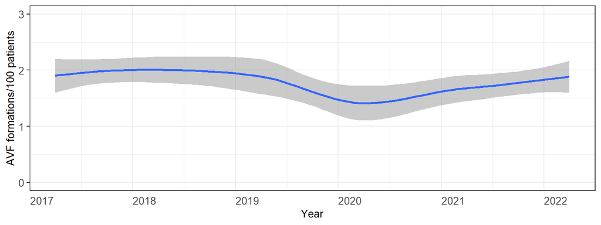

AVF formations by IMD

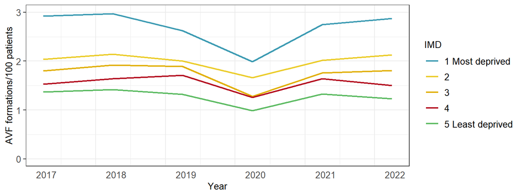

AVF formations by rural/urban

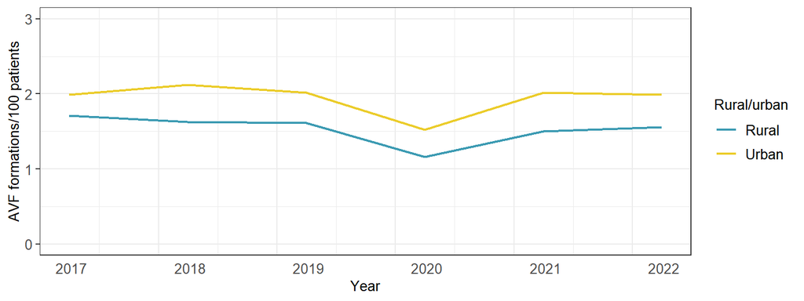

**PD insertions**

PD insertions (overall)

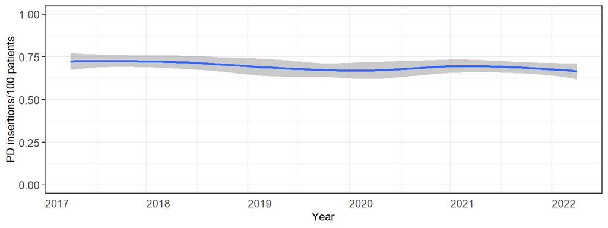

PD insertions by rural/urban

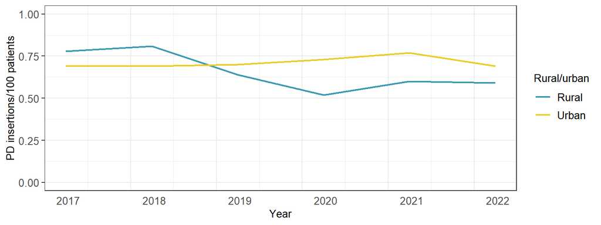